# Comment les pratiques et les habitudes des étudiants peuvent-elles influencer leur temps de travail ?

Amalia, Iruomachi et Yann

18/12/2023

# **Présentation du sujet**

Nous allons nous intéresser à l’impact des différentes habitudes des étudiants sur le temps de travail scolaire fourni. Afin d’y parvenir, nous allons étudier les variables telles que le temps passé en soirée, sur les réseaux sociaux ou plus généralement sur leur téléphone.

Grace au sondage que vous avez mis à notre disposition, où 206 étudiants ont répondu, nous allons faire une analyse de :

- La relation entre le temps de travail par semaine et :
  - Le temps passé sur les réseaux sociaux
  - Le nombre de soirées par semaine
  - Le niveau de consommation d’alcool
  - Le genre

Le but serait donc de trouver une corrélation entre les activités et le temps de travail qui influe grandement les résultats des étudiants. Cette étude nous permettra donc de voir quelle serait l’organisation optimal qu’un étudiant pourrait avoir afin de maximiser ses chances de réussite.

# Le temps de travail hebdomadaire des étudiants

Nous avons questionné les étudiants sur leur temps de travail par semaine. Les réponses sont données en heures consacrées au travail scolaire.

Le résultat obtenu est le suivant :

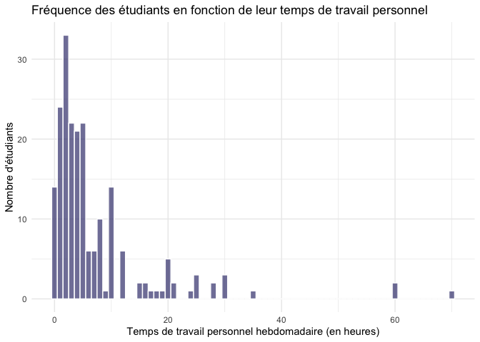

Nous constatons donc que, sur 206 étudiants intérrogés, la majorité consacre entre 0 et 4h de leur temps sur le travail scolaire, avec environ 34 étudiants qui y consacrent 2h.

Nous avons tout de même 14 personnes qui ne travaillent pas. Elles représentent environ 7% des répondants.

Nous pouvons alors nous demander si ces personnes sont influencées par quelque chose d’extérieur comme les réseaux sociaux par exemple.

Passons donc à l’analyse du temps passé sur les réseaux sociaux.

# Temps passé sur les réseaux sociaux

Malgré le fait que les réseaux sociaux constituent une avancée technologique majeure de nos jours, ils peuvent également représenter une source de distraction. Il n’est pas rare de se retrouver à passer des heures à faire défiler du contenu sur TikTok, même lorsque l’on à d’autres choses à faire.

Considérons le cas d’un étudiant qui travaille. Il arrive parfois qu’une brève pause de 5 minutes destinée à se détendre sur les réseaux sociaux se transforme malheureusement en plusieurs heures de distractions, potentiellement utilisables de manière plus productive dans son travail.

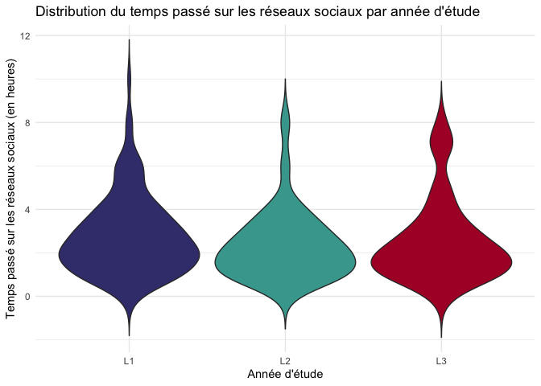

Premièrement on peut constater que peut importe l’année d’étude, les étudiants réagissent de la même manière face à l’utilisation des réseaux sociaux.

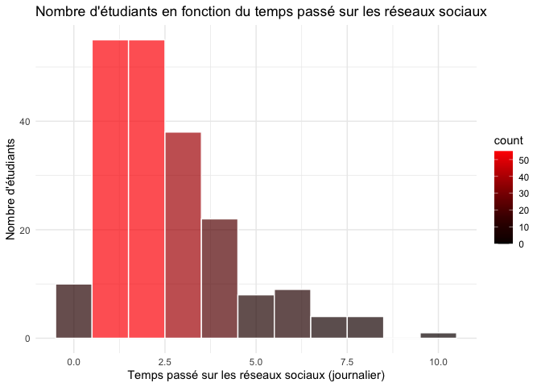

|  | Unique (#) | Missing (%) | Mean | SD | Min | Median | Max |  |
| --- | --- | --- | --- | --- | --- | --- | --- | --- |
| data | 17 | 0 | 2.6 | 1.8 | 0.0 | 2.0 | 10.0 |  |

De plus nous pouvons observer à l’aide de ce graphique que les étudiants ayant répondu à ce sondage passent en moyenne, 2h36 par jour sur les réseaux sociaux.

En tenant compte du fait que la plupart du temps, nous avons plusieurs cours dans la journée et qu’il est ensuite nécessaire de s’occuper des tâches domestiques telles que l’entretien d’un appartement, la préparation des repas, la vaisselle, etc. Si l’on souhaite consacrer du temps au travail en dehors des cours, passer plus de 2 heures sur les réseaux sociaux peut freiner la réussite de ses études.

Regardons maintenant la relation, à l’aide d’une droite de régression, entre le temps de travail accordé par les étudiants et le temps passé sur les réseaux sociaux.

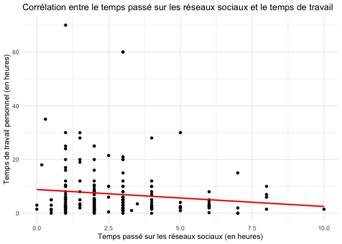

Nous avons donc représenté une régression linéaire en utilisant le temps consacré aux réseaux sociaux et au travail scolaire.

Nous constatons une concentration du nuage de points de plus en plus faible à mesure que le temps consacré aux réseaux sociaux augmente.Lorsqu’une variable augmente, l’autre diminue, cela illustre une tendance descendante.

Cette relation inverse indique une corrélation négative entre le temps alloué au travail et celui passé sur les réseaux sociaux.

Cependant, il faut bien tenir compte du fait que corrélation n’implique pas causalité. Le temps passé sur les réseaux sociaux ne doit pas être automatiquement considéré comme la cause d’une diminution du temps consacré au travail.

# Nombre de soirées hebdomadaire des étudiants

La vie universitaire est une période remplie de stresse mais également de souvenirs. Ces derniers se font souvent durant les soirées étudiantes, là où de nouvelles rencontres naissent. Ce sont des moments de détente qui permettent de se déconnecter un court instant du quotidien de travaux dirigés et d’examens. L’importance d’y participer varie d’un étudiant à un autre, selon son bien-être.

Nous avons donc fait une étude pour voir le nombre de soirées hebdomadaires des étudiants d’Économie. Les résultats sont les suivants :

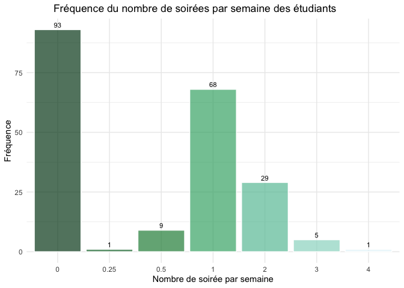

68 d’entre eux préfèrent sortir une fois par semaine.

Et une notable proportion de 29 étudiants optent pour deux sorties hebdomadaires.

Tandis que 6 étudiants courageux se lancent dans l’aventure de 3 à 4 sorties par semaine.

Il faut donc croire que contrairement à ce que l’on pense, les étudiants ne font pas tant de sorties que cela. Les préférences varient tout de même considérablement au sein de la population. L’idée que tous les étudiants sont tentés par les soirées ne correspond donc pas réellement à la réalité vécue par les répondants. C’est peut-être la concession à faire pour avoir le temps de travailler et réussir leur année. Regardons alors si le nombre de soirées a un impact sur le temps de travail.

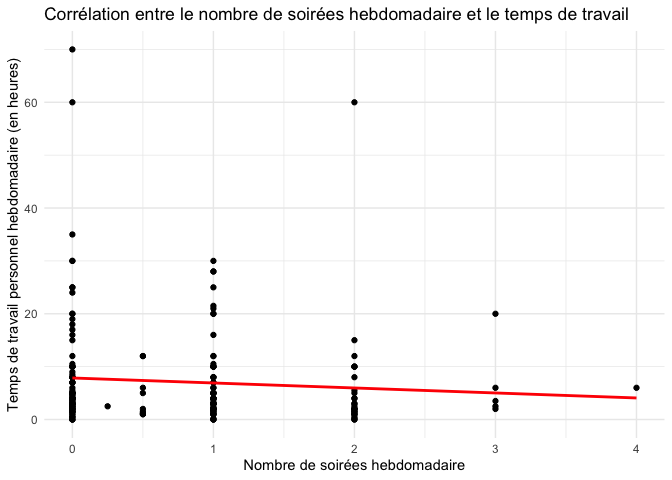

Nous avons tracé une régression linéaire pour examiner la relation entre le nombre de soirées hebdomadaire et le temps consacré au travail scolaire. On constate que plus le nombre de soirées augmente, plus la densité du nuage de points diminue. Cette tendance à la baisse suggère une corrélation négative entre le temps consacré au travail et le nombre de soirées.

Néanmoins, il est important de noter que bien que cette relation inverse soit présente, la corrélation n’est pas particulièrement significative. Il semble donc raisonnable de faire une ou deux soirées par semaine, laissant aux étudiants une pause pour décompresser tout en maintenant un bon rythme de travail.

# La consommation d’alcool

Nous savons maintenant que le fait de faire des soirées n’est pas forcément nocif au travail scolaire (avec modération). Ce qui peut l’être est l’alcool.

L’alcool est dangereux pour la santé. Pour être plus précis, il peut affecter la capacité à penser correctement et prendre des décisions. Il est important de consommer de l’alcool avec beaucoup de modération et d’être conscient des risques. Étudions statistiquement l’impact de l’alcool sur le travail.

Voici un tableau de fréquence de la consommation d’alcool des étudiants :

| Consommation | Fréquence |
| --- | --- |
| Jamais | 72 |
| Moins d’une fois par mois | 34 |
| Moins d’une fois par semaine | 40 |
| Environ une fois par semaine | 39 |
| Plusieurs fois par semaine | 21 |

72 étudiants ne consomment pas d’alcool, ce qui représente environ 35% de la population. L’autre extrême qui est de boire plusieurs fois par semaine concerne 21 étudiants. A peu près le double de ceux qui boivent plusieurs fois par semaine, boivent uniquement une fois par semaine. Et pour finir, 74 étudiants consomment de l’alcool moins d’une fois par semaine, voire moins d’une fois par mois.

On se rend compte que le nombre d’étudiants participants à des soirées ne veut pas nécessairement dire que ce même nombre consomme de l’alcool; c’est assez soulageant !

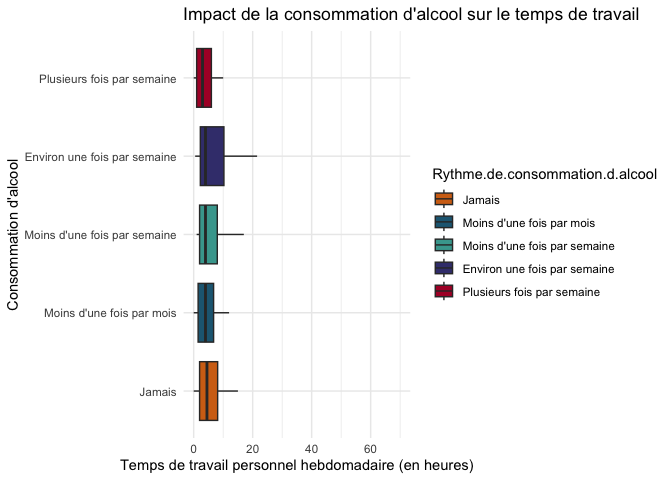

Cela nous montre que l’on peut allier alcool et travail personnel à condition que ce soit raisonnable. Se faire plaisir exceptionnellement ne serait pas nocif sur le temps consacré au travail.

Pour appuyer nos propos, voici un test d’indépendance :

```
##                                  Df Sum Sq Mean Sq F value Pr(>F)
## Rythme.de.consommation.d.alcool   4    472  118.01   1.271  0.283
## Residuals                       201  18663   92.85
```

On peut donc conclure qu’on ne rejette pas l’hypothèse H0 sous le seuil de 5% car notre p-value est supérieur à 0.05 (sa valeur est de 0,283).

# Le genre

Les stéréotypes de genre mènent souvent à dire que les femmes sont plus aptes à être concentrées donc à travailler plus que les hommes. Cela peut être associé à des traits tels que la patience, la minutie. Mais est-ce vrai ? Nous allons le découvrir pour notre échantillon.

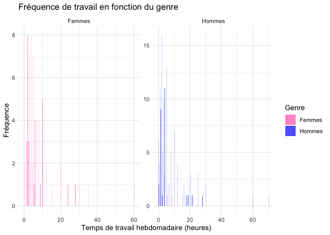

D’après les graphiques ci-dessus, les hommes sont plus nombreux que les femmes à travailler entre 0 et 5h. Or, entre 5h et 10h, nous avons en moyenne une tendance inverse. Entre 10h et 20h, il n’y a pas de différence remarquable. Mais, on constate qu’une seule femme sur les 206 étudiants travaille 30h par semaine, tandis que du côté des hommes il y en a 2.

Nous avons une étudiante qui travaille toutefois 35h par semaine, soit une semaine de travail à temps plein.

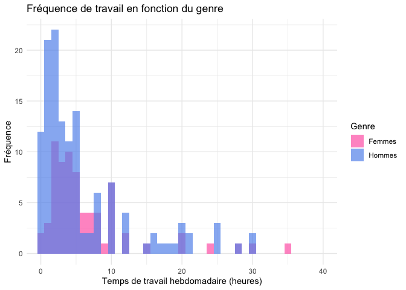

L’étude est donc assez hétérogène et l’échantillon reste assez faible pour pouvoir conclure à un résultat car le nombre d’hommes est très supérieur au nombre de femmes (133 contre 73).

# **Conclusion**

Le résultat que nous avons trouvé peut être faussé dû à un échantillon trop petit. Parfois le choix de réponse dans le questionnaire n’était pas assez précis. Nous avons dû enlever certaines valeurs qui faussaient nos résultats. Par exemple lorsque nous nous interéssiions au facteur temps consacré au travail, certains étudiants avaient répondu qu’ils travaillaient 160h par semaine, ce qui était difficile à croire.